# VIS_assignment 02

Mengyao

2020/9/17

# Loading data

```r
library(ggplot2)
library(sf)
library(rnaturalearth)
library(rnaturalearthdata)
library(tidyverse)
library(ggspatial)
library(cartogram)
library(ggthemes)
library(rgeos)
library(devtools)
```

# World map

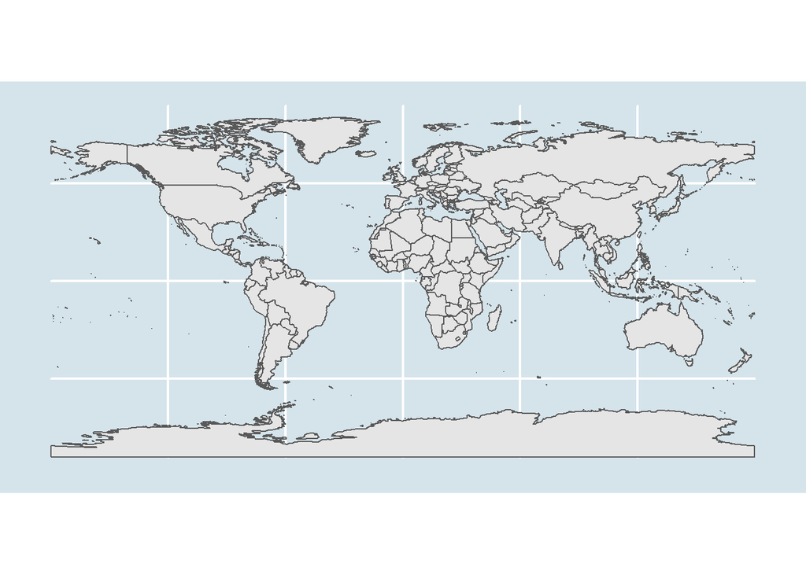

```r
world_map <- ne_countries(scale = 50, returnclass = "sf")
world_map_02 <- ggplot(world_map) +
  geom_sf() +
  theme_economist()
world_map_02
```

# Provinces in China

As I was born and raised in mainland China, all maps I saw treated Taiwan as a province of China. It is weird to see that Taiwan is not included in this map. I believe that politics are involved in maps.

```r
devtools::install_github("ropensci/rnaturalearthhires")
```

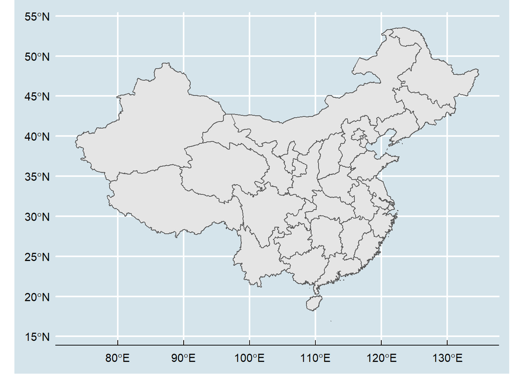

```r
china_province <- ne_states(country = "China", returnclass = "sf")
china_map <- ggplot(china_province) +
  geom_sf() +
  theme_economist()

china_map
```

# Reprojecting map data

Adding scale bar

```r
china_map +
  annotation_scale()
```

```
## Scale on map varies by more than 10%, scale bar may be inaccurate
```

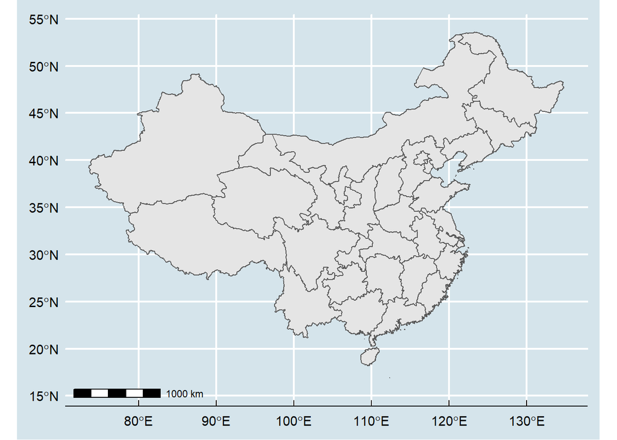

Finding three coordinate reference systems for China. As there are very limited coordinate reference systems for China available on the spatial reference website, I tried to use Korea and India, which are adjacent countries, to present more noticeable change of projections.

```r
china_albers <- "+proj=aea +ellps=krass +lon_0=105 +lat_1=25 +lat_2=47 105 36 0.00 3847866.97 104d36'54 36d25'9 -33897.90 3895309.74 104d25'36.9E 36d52'41N -50158.40 3947261.73"
korea <- "+proj=tmerc +lat_0=38 +lon_0=127 +k=1 +x_0=200000 +y_0=500000 +ellps=GRS80 +units=m +no_defs"
india <- "+proj=aea +lat_1=28 +lat_2=12 +lat_0=20 +lon_0=78 +x_0=2000000 +y_0=2000000 +ellps=WGS84 +datum=WGS84 +units=m +no_defs"
```

How China looks in each of these three projections:

1. china_albers

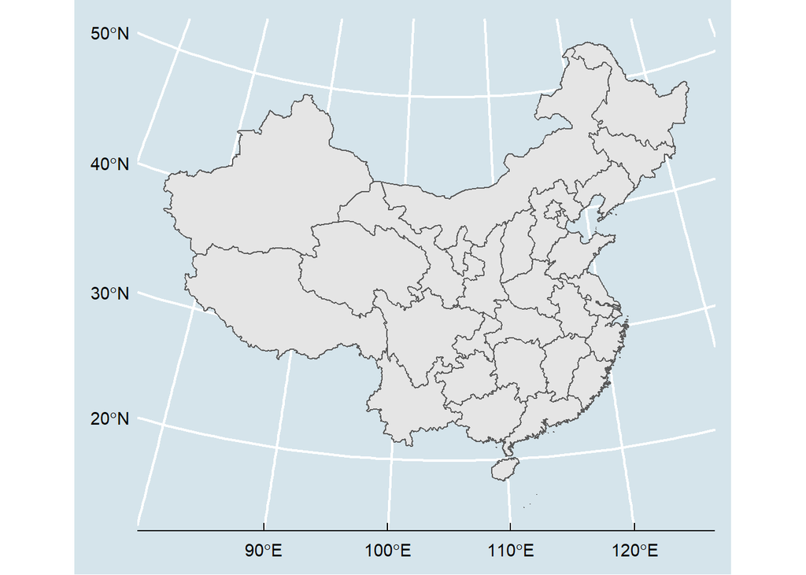

```r
china_map +
  geom_sf() +
  coord_sf(crs = china_albers) +
  theme_economist()
```

2. korea

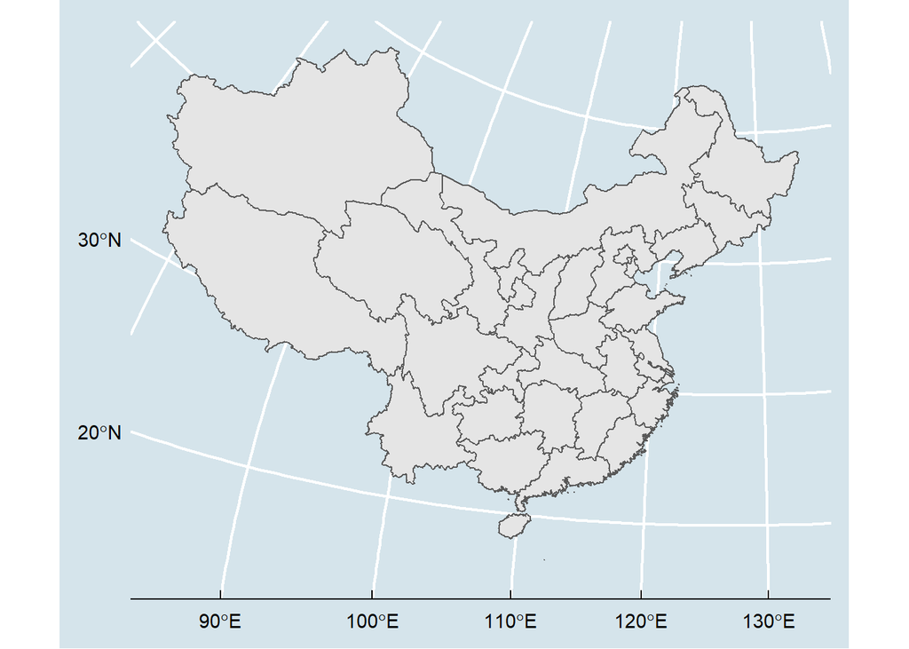

```r
china_map +
  geom_sf() +
  coord_sf(crs = korea) +
  theme_economist()
```

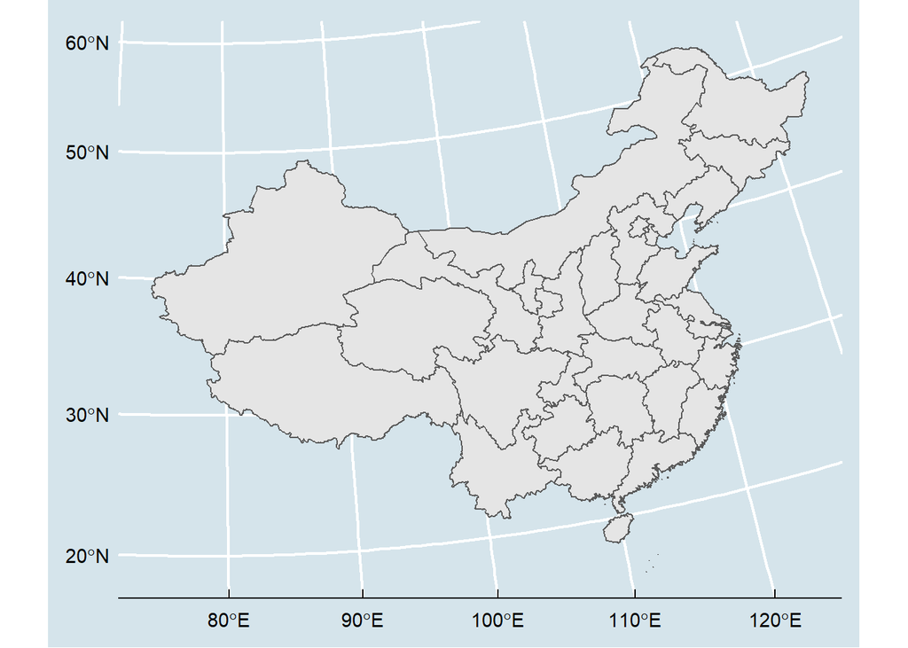

```r
china_map +
  geom_sf() +
  coord_sf(crs = india) +
  theme_economist()
```

# Transforming coordinate systems

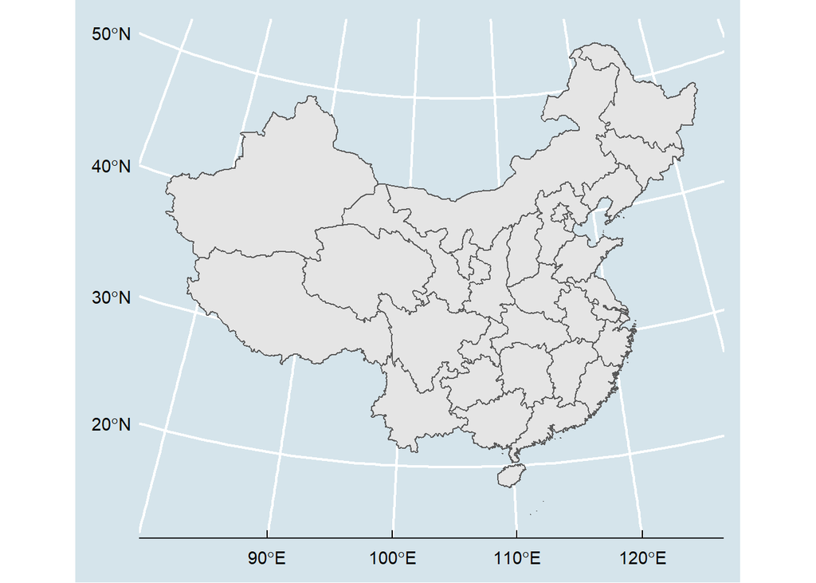

```r
provinces_transformed <- china_province %>%
  st_transform(crs = china_albers)

ggplot(provinces_transformed) +
  geom_sf() +
  theme_economist()
```

# Joining data

I have made a file with province-level data on COVID-19 cases based on China’s National Health Commission statistics. I have joined it with my china_province dataframe.

```r
covid_china <- read_csv("covid19_china.csv")
covid_provinces <- provinces_transformed %>%
  left_join(covid_china, by = "name") %>%
  filter(population != "NA") %>%
  select(name, cases, population)
```

# Choropleth map

I have applied a logarithm scale since the differences of cases between provinces are quite big. Most cases (Over 60,000) were located in Hubei Province. Using a normal scale will have all other provinces presented in dark blue.

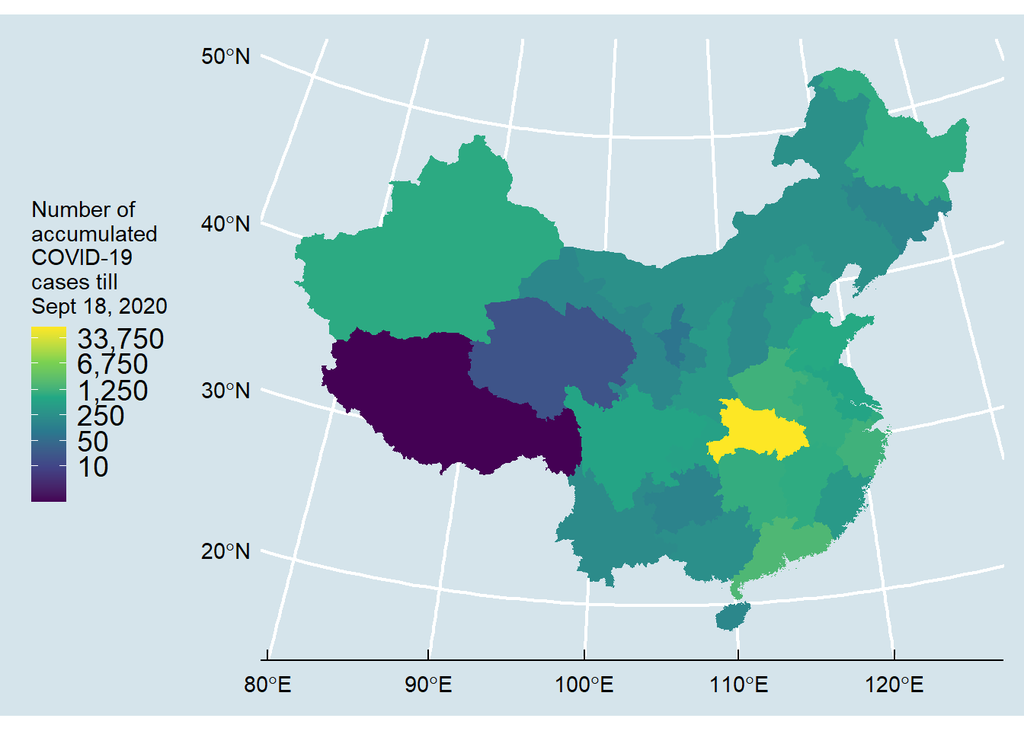

```r
ggplot(covid_provinces,
       aes(fill = cases)) +
  geom_sf(color = NA) +
  scale_fill_viridis_c(
    name = "Number of \naccumulated\nCOVID-19\ncases till\nSept 18, 2020",
    trans = "log",
    breaks = c(0, 10, 50, 250, 1250, 6750, 33750, 70000),
    labels = formatC(c(0, 10, 50, 250, 1250, 6750, 33750, 70000),
                     big.mark = ",", format = "f", digits = 0)) +
  theme_economist() +
  theme(legend.background = element_blank(),
        legend.direction = "vertical",
        legend.position = "left")
```

# Cartograms

## Continuous cartogram

```r
covid_cartogram_cont <- covid_provinces %>%
  cartogram_cont("population")
```

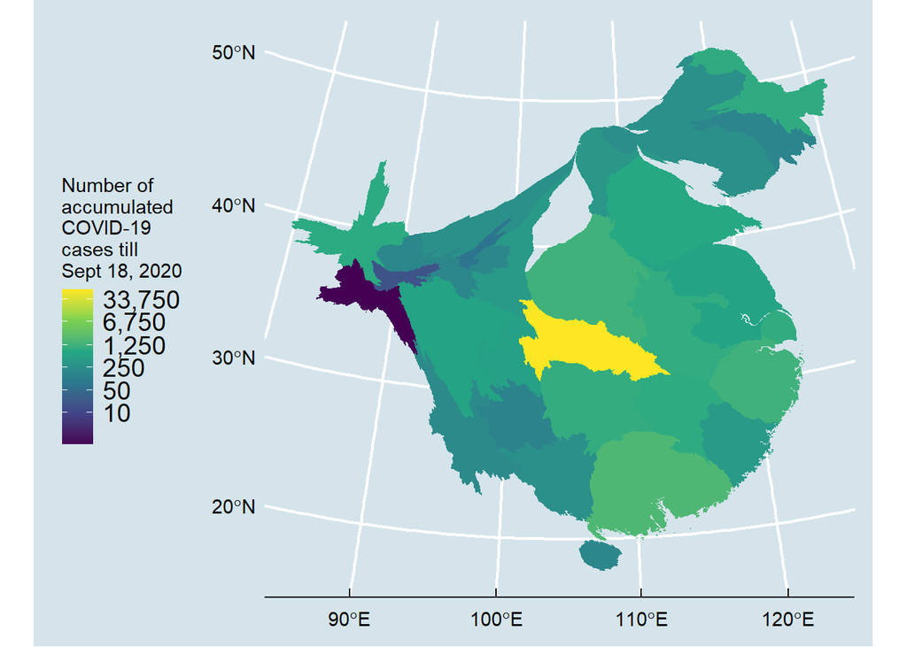

```r
ggplot(covid_cartogram_cont,
       aes(fill = cases)) +
  geom_sf(color = NA) +
  scale_fill_viridis_c(
    name = "Number of \naccumulated\nCOVID-19\ncases till\nSept 18, 2020",
    trans = "log",
    breaks = c(0, 10, 50, 250, 1250, 6750, 33750, 70000),
    labels = formatC(c(0, 10, 50, 250, 1250, 6750, 33750, 70000),
                     big.mark = ",", format = "f", digits = 0)) +
  theme_economist() +
  theme(legend.background = element_blank(),
        legend.direction = "vertical",
        legend.position = "left")
```

## Non-continuous cartogram

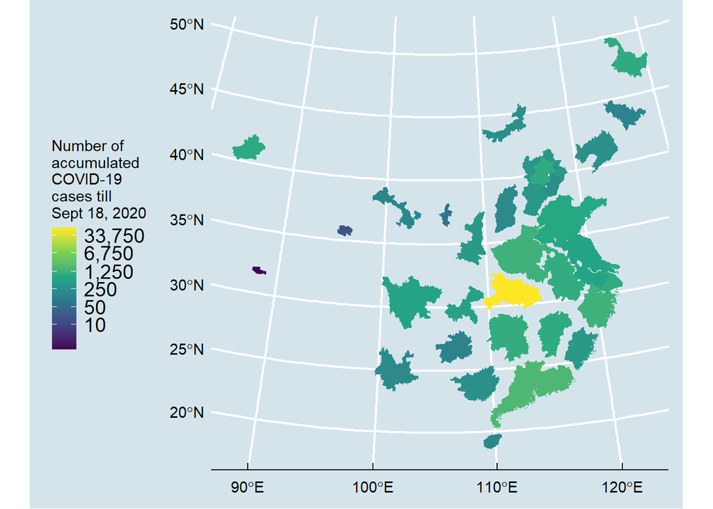

```r
covid_cartogram_ncont <- covid_provinces %>%
  cartogram_ncont("population")

ggplot(covid_cartogram_ncont,
       aes(fill = cases)) +
  geom_sf(color = NA) +
  scale_fill_viridis_c(
    name = "Number of \naccumulated\nCOVID-19\ncases till\nSept 18, 2020",
    trans = "log",
    breaks = c(0, 10, 50, 250, 1250, 6750, 33750, 70000),
    labels = formatC(c(0, 10, 50, 250, 1250, 6750, 33750, 70000),
                     big.mark = ",", format = "f", digits = 0)) +
  theme_economist() +
  theme(legend.background = element_blank(),
        legend.direction = "vertical",
        legend.position = "left")
```

## Dorling Cartogram

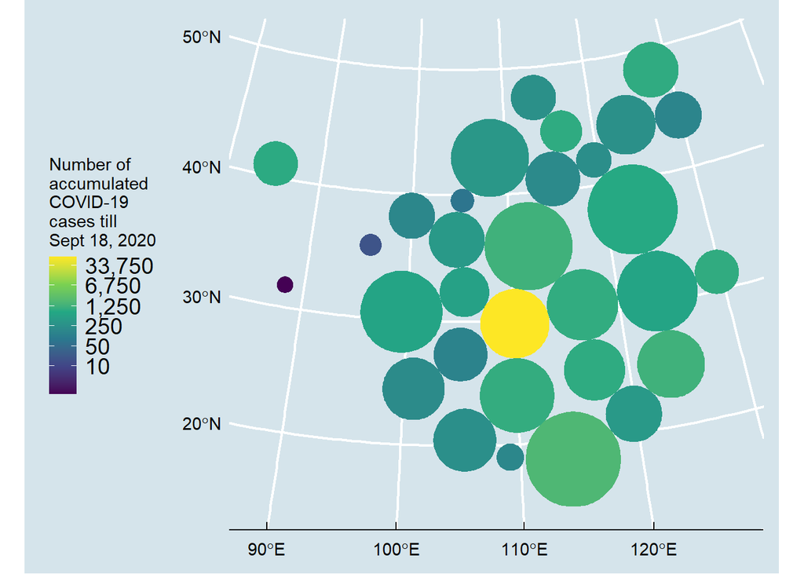

```r
covid_cartogram_dorling <- covid_provinces %>%
  cartogram_dorling("population")

ggplot(covid_cartogram_dorling,
       aes(fill = cases)) +
  geom_sf(color = NA) +
  scale_fill_viridis_c(
    name = "Number of \naccumulated\nCOVID-19\ncases till\nSept 18, 2020",
    trans = "log",
    breaks = c(0, 10, 50, 250, 1250, 6750, 33750, 70000),
    labels = formatC(c(0, 10, 50, 250, 1250, 6750, 33750, 70000),
                     big.mark = ",", format = "f", digits = 0)) +
  theme_economist() +
  theme(legend.background = element_blank(),
        legend.direction = "vertical",
        legend.position = "left")
```

## Proportional symbol map

```r
covid_centeroids <- covid_provinces %>%
  st_centroid()
```

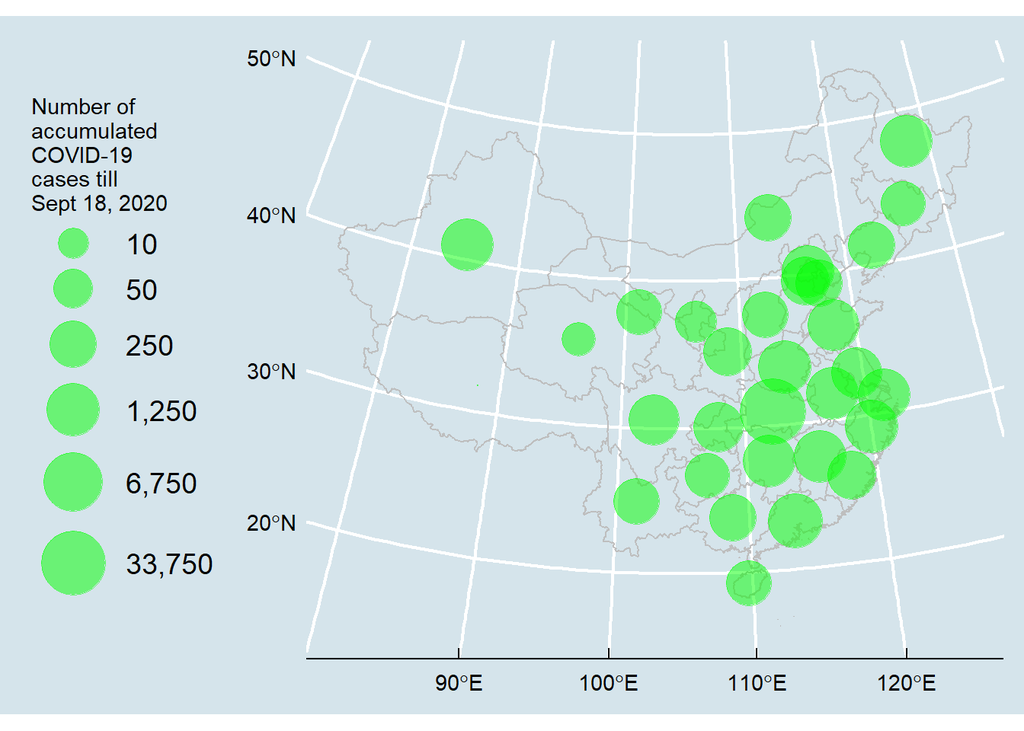

```r
ggplot(provinces_transformed) +
  geom_sf(fill = NA, color = "gray") +
  geom_sf(data = covid_centeroids,
          aes(size = cases),
          alpha = 0.5,
          color = "green") +
  scale_size_continuous(
    name = "Number of \naccumulated\nCOVID-19\ncases till\nSept 18, 2020",
    trans = "log",
    breaks = c(0, 10, 50, 250, 1250, 6750, 33750, 70000),
    labels = formatC(c(0, 10, 50, 250, 1250, 6750, 33750, 70000),
                     big.mark = ",", format = "f", digits = 0),
    range =c(0,15)) +
  theme_economist() +
  theme(legend.background = element_blank(),
        legend.direction = "vertical",
        legend.position = "left")
```